# Capitulo 1: Introduccion a Estadistica en R

Resumen de lecciones aprendidas de curso de Datacamp

Joshua Suasnabar Huapaya - jsuasnabarh@gmail.com - [Linkedin](https://www.linkedin.com/in/jsuasnabarh/)

20 de Enero del 2022

El presente notebook es una recopilacion de informacion del capitulo 1 del curso de Introduccion a la estadistica con R donde se explicara un resumen de lo aprendido para la comunidad R en espaniol.

## Estadistica:

La practica y estudio de la recoleccion y el analisis de los datos. Con la estadistica podemos responder las siguientes preguntas:

- Que tan probable es que alguien compre un producto? Es probable que una persona compre si usa un meodo de pago distinto?
- Cuantos clientes hospedados hay el dia de hoy? Como puedo optimizar la asignacion de habitaciones?
- Cuantas tallas de Jean deben fabricarse para que le quede al 95% de la poblacion?
- A/B Test: Que anuncio es mas efectivo para que las personas compren un producto?

### Tipos de estadistica:

- *Estadistica descriptiva:* Describe y resume data. Ejemplos:
  - 50% de mis amigos manejan para ir a trabajar.
  - 25% toman bus.
  - 25% van en bicicleta.
- *Estadistica inferencial:* Usa una muestra de la poblacion para hacer inferencias sobre el universo total. Ejemplo:
  - Que porcentaje de personas maneja para ir a trabajar?

### Tipos de datos:

- *Numerica (Cuantitativa):*
  - Continua (Medible): Velocidad de un auto.
  - Discreta (Contable): Numero de mascotas.
- *Categorica:*
  - Nominal (Desordenada): Casado, Soltero.
  - Ordinal (Ordenada): Primero, Segundo, Tercero.

  Sobre la data categorica debemos tomar en consideracion que a veces puede ser presentada como numeros. Por ejemplo:
  - Casado (1) Soltero (0)

### Por que el tipo de dato es importante?

Porque nos ayuda a saber que tipo de resumen estadistico puedo aplicar con cada tipo de dato. A continuacion un ejemplo con el dataset TITANIC:

Importamos el dataset:

```r
data <- read.csv("datasets/titanic/train.csv")

head(data)
```

```
##   PassengerId Survived Pclass
## 1           1        0      3
## 2           2        1      1
## 3           3        1      3
## 4           4        1      1
## 5           5        0      3
## 6           6        0      3
##                                                  Name    Sex Age SibSp Parch
## 1                             Braund, Mr. Owen Harris   male  22     1     0
## 2 Cumings, Mrs. John Bradley (Florence Briggs Thayer) female  38     1     0
## 3                              Heikkinen, Miss. Laina female  26     0     0
## 4        Futrelle, Mrs. Jacques Heath (Lily May Peel) female  35     1     0
## 5                            Allen, Mr. William Henry   male  35     0     0
## 6                                    Moran, Mr. James   male  NA     0     0
##             Ticket    Fare Cabin Embarked
## 1        A/5 21171  7.2500              S
## 2         PC 17599 71.2833   C85        C
## 3 STON/O2. 3101282  7.9250              S
## 4           113803 53.1000  C123        S
## 5           373450  8.0500              S
## 6           330877  8.4583              Q
```

Sabiendo que Sexo es una variable *categorica nominal* podriamos aplicar un conteo de los datos:

```r
data %>%
  count(Sex)
```

```
##      Sex   n
## 1 female 314
## 2   male 577
```

Sabiendo que la edad es una variable con *cuantitativa discreta* podemos hacer un histograma para saber la frecuencia de pasajeros por edad, e inclusive podemos gracias a la versatilidad de la libreria ggplot tener la discretizacion por la *variable categorica nominal* sexo.

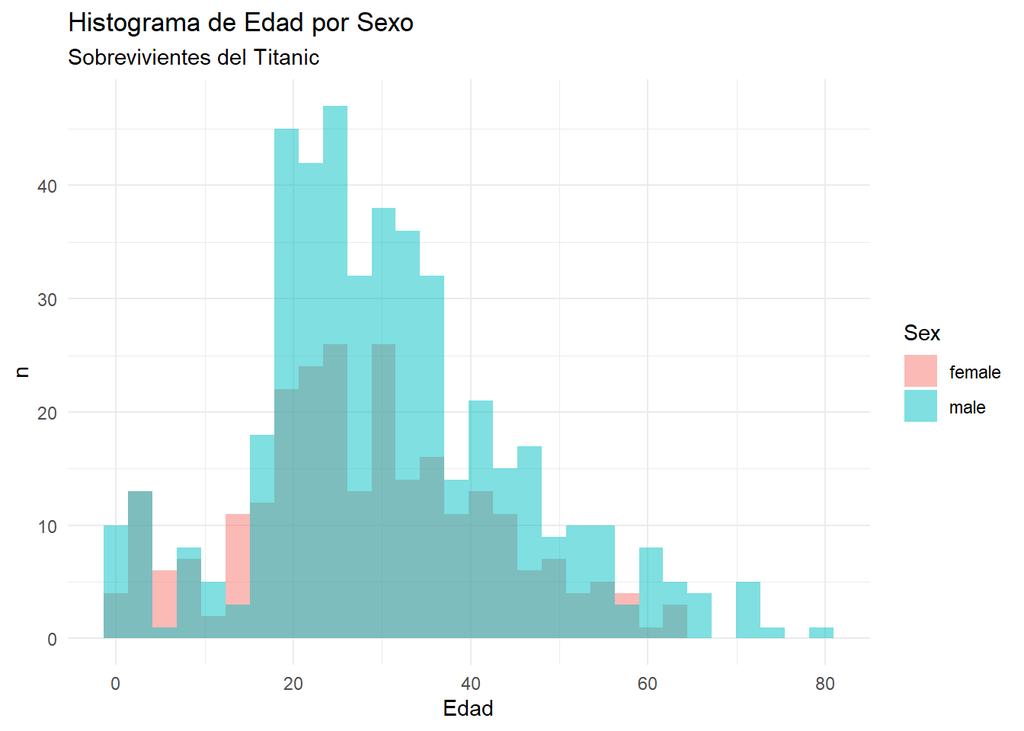

```r
ggplot(data,aes(x=Age,fill=Sex))+
  geom_histogram(alpha=0.5, position="identity")+
  theme_minimal()+
  labs(
    title = "Histograma de Edad por Sexo",
    subtitle = "Sobrevivientes del Titanic",
    x = "Edad",
    y = "n")
```